# Analysis of RNAseq data in R and Bioconductor (part 3)

## Likelihood-ratio test

We can use the **plotCounts()** to get review expression profile of a gene, one at a time. We define the gene of interest to **gene** parameter and **intgroup** to specify metadata column to group counts by.

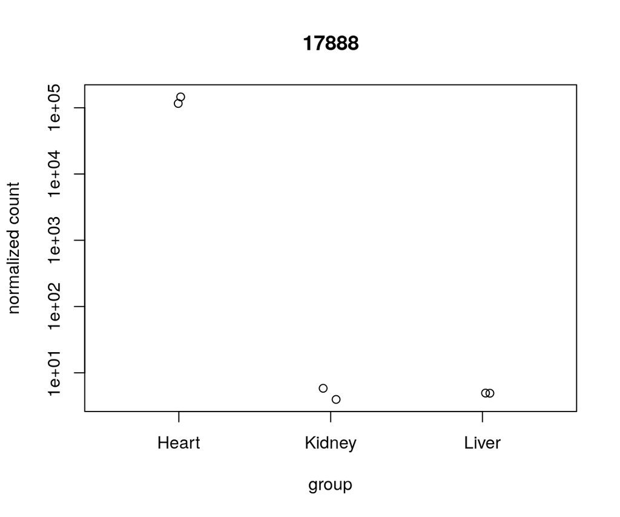

```r
plotCounts(dds2, gene = "17888", intgroup = "Tissue")
```

## Filter with LRT results

Clustering is typically done on the transformed normalized counts. To make it easier to find interesting clusters we can subset our rlog transformed gene expression matrix to those genes significant in our LRT test. This filters the ~45% of genes that are not changing across our experiment.

```r
sigChanges <- rownames(acrossGroups)[acrossGroups$padj < 0.01 & !is.na(acrossGroups$padj)]
sigMat <- rlogMatrix[rownames(rlogMatrix) %in% sigChanges, ]
nrow(rlogMatrix)
```

```
## [1] 14454
```

```r
nrow(sigMat)
```

```
## [1] 8094
```

## Clustering genes and samples

We can pass our filtered matrix of expression to the **pheatmap()** function and set the **scale** parameter to *row* to allow for clustering of relative changes in gene expression (this does a by gene Z-score). Additionally due to the large number of genes, we turn rowname off with the **show_rownames** function.

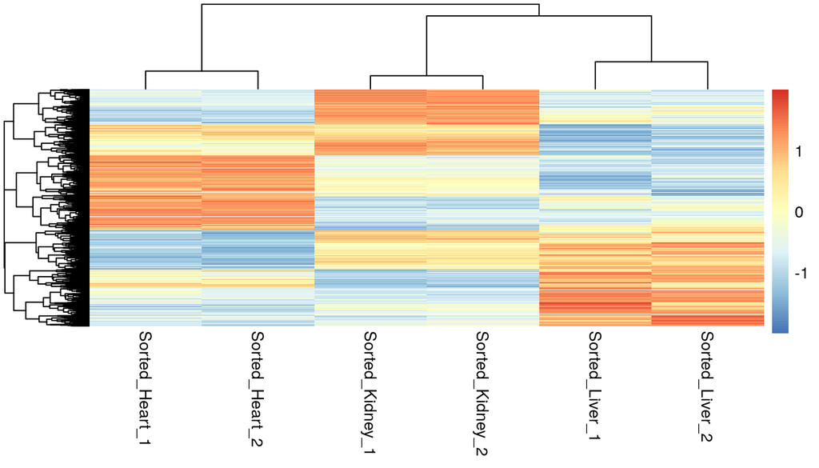

```r
library(pheatmap)
pheatmap(sigMat, scale = "row", show_rownames = FALSE)
```

## Clustering genes and samples

This approach means we can isolate patterns of gene expression rather than focus on absolute values. You can also see that genes and samples have been grouped together based on similarity in a hierarchical clustering tree. Again this makes it easier to see patterns.

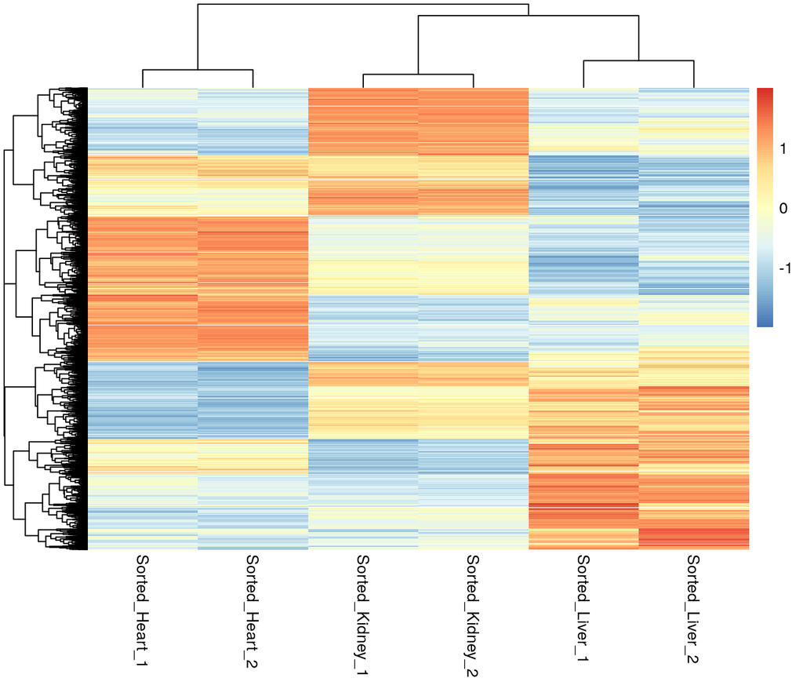

```r
pheatmap(sigMat, scale = "row", show_rownames = FALSE)
```

## Clustering genes and samples

Now we have a visual representation of changes in gene expression across samples we can use the clustering to derive groups of genes with similar expression patterns. Gene with similar expression profiles may share functional roles and so we can use these groups to further evaluate our gene expression data.

Many approaches to identifying clustered groups of genes exist including K-means, SOM and HOPACH.

The pheatmap package has in built methods for K means and hierarchical clustering. For K means we can simply provide a desired number of clusters to the **kmeans_k** parameter. For the moment we will just pick 7.

```r
library(pheatmap)
set.seed(42)
k <- pheatmap(sigMat, scale = "row", kmeans_k = 7)
```

## Clustering genes and samples

The resulting plot no longer shows our individual genes but the average relative expression of genes within a cluster.

The heatmap rownames show the cluster name and importantly the number of genes within each cluster.

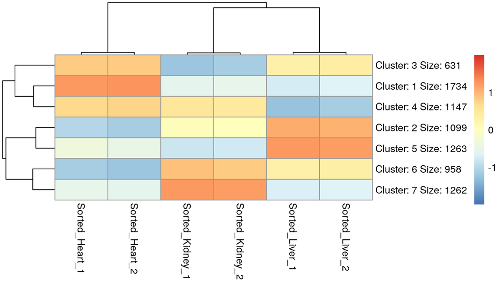

```r
library(pheatmap)
set.seed(42)
k <- pheatmap(sigMat, scale = "row", kmeans_k = 7)
```

## Clustering genes and samples

The **pheatmap()** function returns information on clustering. This is returned as a list, from which the K-means clustering the assignment of genes to clusters can be extracted.

```r
names(k$kmeans)
```

```
## [1] "cluster"      "centers"      "totss"        "withinss"     "tot.withinss"
## [6] "betweenss"    "size"         "iter"         "ifault"
```

```r
clusterDF <- as.data.frame(factor(k$kmeans$cluster))
colnames(clusterDF) <- "Cluster"
clusterDF[1:10, , drop = FALSE]
```

```
##           Cluster
## 20671           1
## 27395           3
## 18777           6
## 21399           2
## 108664          6
## 319263          5
## 76187           6
## 70675           5
## 73824           2
## 100039596       6
```

## Clustering genes and samples

We can now plot our full heatmap highlighting the membership of genes to clusters.

We add an additional row annotation by providing a data.frame of desired annotation with rownames matching between our annotation data.frame and our rlog transformed matrix to the **annotation_row** parameter.

```r
OrderByCluster <- sigMat[order(clusterDF$Cluster), ]

pheatmap(OrderByCluster, scale = "row", annotation_row = clusterDF, show_rownames = FALSE,
    cluster_rows = FALSE)
```

## Clustering genes and samples

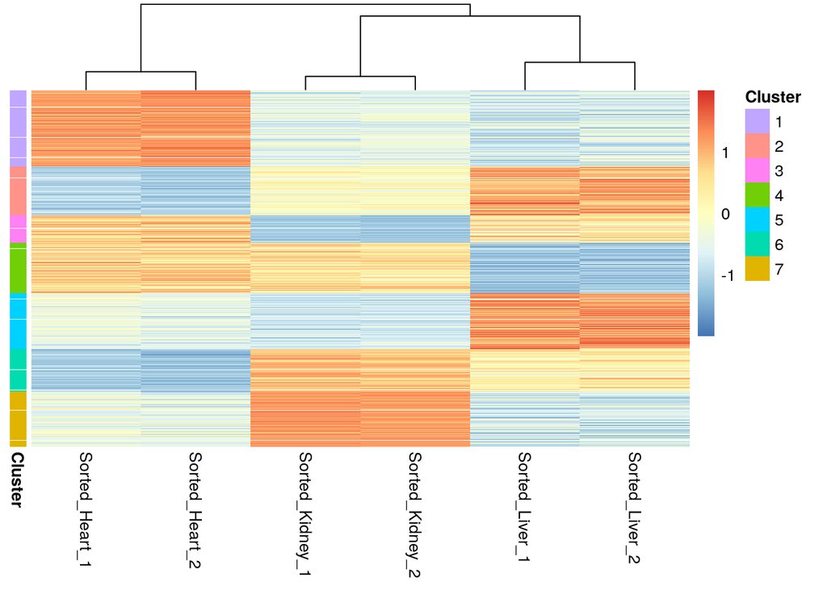

```r
OrderByCluster <- sigMat[order(clusterDF$Cluster), ]

pheatmap(OrderByCluster, scale = "row", annotation_row = clusterDF, show_rownames = FALSE,
    cluster_rows = FALSE)
```

## Identifying optimal clusters

When doing clustering you will need to try and optimize the number of clusters selected. Methods exist to help identify the ideal number.

One such method is to assess the **silhouette** score at different successive cluster numbers and choose the cluster number with the highest mean **silhouette** score.

The **Silhouette** method evaluates the similarity of cluster members to the similarity between clusters as below.

For all genes/samples, the dissimilarity for a cluster member to its own cluster , $ai$, is calculated as the mean distance between a cluster member and all other members of that cluster. Further to this the minimun, mean dissimilarity of the cluster member to members of other clusters is calculated, $bi$.

$S i = ( b i − a i ) / m a x ( a i , b i )$

## Identifying number of clusters

We can use the NbClust package to calculate the **Silhoutte** scores over successive cluster numbers. We supply the scaled matrix to the *NbClust* function and set the min and maximum cluster numbers to try using the **min.nc** and **max.nc** respectively.

We can retrieve the optimal cluster number from the **Best.nc** slot of our result list. Here we see the number is lower at 3. Maybe a cluster for every sample group’s unique gene expression signature.

```r
library(NbClust)
rowScaledMat <- t(scale(t(sigMat)))
clusterNum <- NbClust(rowScaledMat, distance = "euclidean", min.nc = 2, max.nc = 12,
    method = "kmeans", index = "silhouette")

clusterNum$Best.nc
```

```
## Number_clusters     Value_Index
##          3.0000          0.4956
```

## Identifying number of clusters

We can the use the **Best.partition** slot to extract the cluster membership as we did with pheatmap.

We can arrange our matrix by using the **match** function between the row names of our matrix and the names of genes in our new cluster membership vector.

```r
clusterNum$Best.partition[1:10]
```

```
##     20671     27395     18777     21399    108664    319263     76187     70675
##         2         2         1         3         1         3         1         3
##     73824 100039596
##         3         1
```

```r
orderedCluster <- sort(clusterNum$Best.partition)
sigMat <- sigMat[match(names(orderedCluster), rownames(sigMat)), ]
```

## Identifying number of clusters

We can now visualize the new clustering alongside our old clustering. In this case the order of genes is determined by our optimized clustering. While our labeled clusters were derived from our original pheatmap clustering. We can clearly see how these clusters overlap.

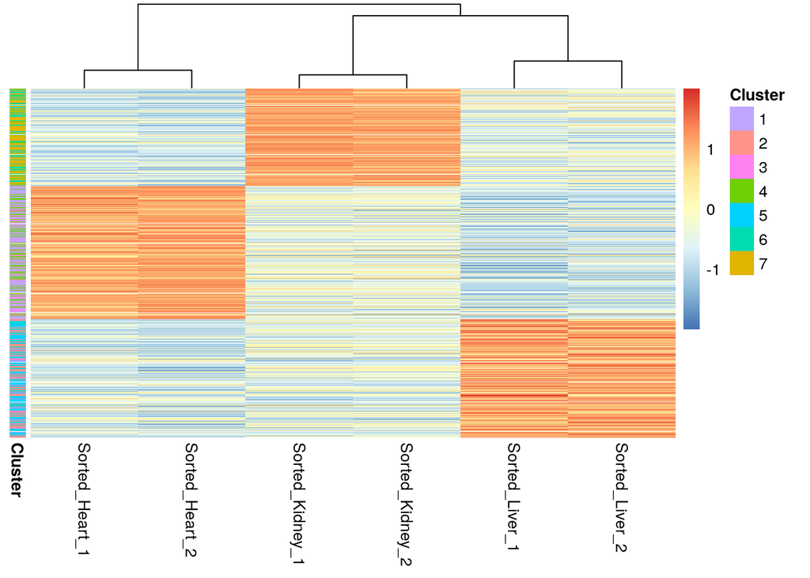

```r
pheatmap(sigMat, scale = "row", annotation_row = clusterDF, show_rownames = FALSE,
    cluster_rows = FALSE)
```

## Identifying number of clusters

We can see that we have lost some of the patterns in our dataset from this lower resolution clustering. If this includes a pattern of gene expression you are specifically interested in that could be problematic.

Often there is a balance as you trade off:

- Finding the most empirically different clusters through approaches like silhouette.
- Finding the pattern in clusters that is biologically relevant to your experiment.

# Time for an exercise

Link_to_exercises

Link_to_answers